# **Capstone: Comparative Machine Learning Approaches for Predicting Scale Score Averages**

### **Data Preparation and Processing**

#### **Important: I added comments within the code and/or before/after the code for added explanation.**

```python
# Import packages

import pandas as pd
import matplotlib.pyplot as plt
import seaborn as sns
import re
import kagglehub
import os
from IPython.display import display
import numpy as np
import joblib
import time
from collections import Counter

from sklearn.model_selection import train_test_split, GridSearchCV, cross_val_score
from sklearn.linear_model import LinearRegression
from sklearn.metrics import mean_squared_error, r2_score, mean_absolute_error, classification_report, confusion_matrix, accuracy_score
from sklearn.ensemble import RandomForestRegressor, StackingRegressor, VotingClassifier, VotingRegressor
from sklearn.linear_model import LinearRegression
from sklearn.preprocessing import StandardScaler, PolynomialFeatures
from sklearn.feature_selection import RFE
from sklearn.impute import KNNImputer
from sklearn.neural_network import MLPRegressor
from xgboost import XGBRegressor

# Enable experimental IterativeImputer
from sklearn.experimental import enable_iterative_imputer
from sklearn.impute import IterativeImputer
from sklearn.linear_model import BayesianRidge

# Suppress all warnings
import warnings
warnings.filterwarnings('ignore')

# magic word for producing visualizations in Jupyter Notebook
%matplotlib inline

# Ensure all columns are displayed
pd.set_option('display.max_columns', None)  # Show all columns
pd.set_option('display.width', None)       # Adjust display width to avoid wrapping
pd.set_option('display.max_colwidth', None) # Show full content of each column (if needed)

# Define a function to print bold headers
def print_bold(text):
    print(f"\033[1m{text}\033[0m")
```

## **Data**

The datasets used in this study is taken from Delaware Open Data Council. Two datasets are used in this study, ‘student assessment performance’ dataset and ‘student discipline’ dataset.

> Student Assessment Performance dataset (assessment.csv): https://data.delaware.gov/Education/Student-Assessment-Performance/ms6b-mt82/about_data Student Discipline (discipline.csv): https://data.delaware.gov/Education/Student-Discipline/yr4w-jdi4/about_data

### **Research Question**

**How do traditional regression models compare to tree-based models in predicting school-level Scale Score Averages, based on predictive accuracy and model performance metrics?**

## **Hypothesis**

**Null Hypothesis (H₀):** There is no significant difference in predictive accuracy between tree-based models (Decision Tree, XGBoost) and traditional regression models (Ridge Regression, Lasso Regression) in predicting Scale Score Averages.

**Alternative Hypothesis (H₁):** Tree-based models (Decision Tree, XGBoost) demonstrate significantly higher predictive accuracy than traditional regression models (Ridge Regression, Lasso Regression) in predicting Scale Score Averages.

#### **Dataset 1**

**Type: CSV File**

**Dataset variables discipline dataset:**

- **School Year:** School year for which record is applicable. For example, 2016 = the school year that ended in June 2016.The school year for which the record is appropriate—for example, 2016 = the school year that ended in June 2016.
- **District Code:** Number representing each School District. Statewide data rows will have “0” in this column.
- **District:** Full name of the School District. Statewide data rows have "State of Delaware" in this column.
- **School Code:** Number representing each School within the school district. Statewide or Districtwide data rows will have “0” in this column.
- **Organization:** Full name of the Organization, the school, if the School Code is given in the row. Districtwide data rows provide the full name of the School District. Statewide rows give "State of Delaware" in this column.
- **Race:** Represents the race/ethnicity of the unique group of students within a school/district.
- **Gender:** Represents the gender of the unique group of students within a school/district.
- **Grade:** Represents the grade level of the unique group of students within a school/district.
- **SpecialDemo:** Represents the special population status of the unique group of students within a school/district.
- **Geography:** Represents the geography of the unique group of students within a school/district.
- **Subgroup:** Names the unique group of students within a school/district described by the combination of Race, Gender, Grade, SpecialDemo, and Geography.
- **Category:** The category of disciplinary action used.
- **Rowstatus:** Indicates whether the aggregate data in this row has either been REDACTED or REPORTED. Specific data has been hidden if redacted to comply with state and federal privacy laws. If you would like more information, you can contact the Delaware Department of Education.
- **Students:** The number of students in the specified subgroup who received the disciplinary action
- **Enrollment:** The number of students enrolled in the specified organization.
- **PctEnrollment:** The percent of students receiving the disciplinary action. This is the number of disciplined students divided by the number of enrolled students.
- **Incidents:** The total number of incidents that resulted in the specified disciplinary action for the specified student demographic
- **AvgDuration:** The average number of days of the specified disciplinary action for the specified student demographic

#### **Dataset 2**

**Type: CSV File**

**Dataset variables assessment dataset:**

- **School Year:** School year for which record is applicable. For example, 2016 = the school year that ended in June 2016.The school year for which the record is relevant—for example, 2016 = the school year that ended in June 2016.
- **District Code:** Number representing each School District. Statewide data rows will have “0” in this column.
- **District:** Full name of the School District. Statewide data rows have "State of Delaware" in this column.
- **School Code:** Number representing each School within the school district. Statewide or Districtwide data rows will have “0” in this column.
- **Organization:** Full name of the Organization, which is the school if the School Code is given in the row. Districtwide data rows provide the full name of the School District. Statewide rows give "State of Delaware" in this column.
- **Assessment Name:** Statewide summative assessment name.
- **ContentArea:** Statewide summative assessment subject (or content area).
- **Race:** Represents the race/ethnicity of the unique group of students within a school/district.
- **Gender:** Represents the gender of a student. Male, Female, and All Students as a whole, disregarding the gender orientation of an individual student.
- **Grade:** Represents the grade level of the unique group of students within a school/district.
- **SpecialDemo:** Represents the special population status of the unique group of students within a school/district.
- **Geography:** Represents the geography of the unique group of students within a school/district. Geography can have the following values: ALL – all geographies combined
- **Subgroup:** Names the unique group of students within a school/district described by the combination of Race, Gender, Grade, SpecialDemo, and Geography.
- **Rowstatus:** Indicates whether the aggregate data in this row has either been REDACTED or REPORTED.
- **Tested:** The number of students who completed the statewide summative assessment listed with a valid score
- **Proficient:** The number of students who earned a proficient achievement level. This is typically considered as three or above.
- **PctProficient:** The percent of students who earned an achievement level considered proficient.
- **ScaleScoreAvg:** The average scale score for the specified group of students.

### **Data storing: All datasets used here are saved in my local data store for a seamless process.**

#### **Below are customized functions for checking data quality and tidiness**

```python
def analyze_dataset(df, dataset_name):
    """
    Function to analyze a given dataset.
    Displays basic dataset information and a preview of the data.

    Parameters:
    df (DataFrame): The DataFrame to analyze.

    Returns:
    None
    """
    # Get the total number of rows and columns
    print(f"\033[1m\nDataset: {dataset_name} \033[0m")
    row_count, column_count = df.shape
    print(f"\033[1m\nTotal number of rows: {row_count} \033[0m")
    print(f"\033[1mTotal number of columns: {column_count} \033[0m\n")

    # Display the first 5 rows of the dataset
    print("\nFirst 3 rows of the dataset:")
    display(df.head(n=3))

    # Display all column names
    print("\n\nAll Columns in the Dataset:")
    print(df.columns.tolist())

    # Identify and list repeated (duplicate) column names
    repeated_columns = df.columns[df.columns.duplicated()].tolist()

    # Display the repeated columns
    if repeated_columns:
        print("\nRepeated Columns:")
        print(repeated_columns)
    else:
        print("\nNo repeated columns found.")
```

```python
def quality_issue_inspection_part1(df, dataset_name):
    """
    Function to do quality inspection on a given dataset.
    Displays missing values, duplicate rows, invalid values, outliers,
    trailing spaces, column entries with mixed format, non-numeric data
    in numeric columns, and numeric data in non-numeric columns.

    Parameters:
    df (DataFrame): The DataFrame to analyze.
    dataset_name (str): Name of the dataset.

    Returns:
    None
    """
    # Bold formatting
    bold_start = "\033[1m"
    bold_end = "\033[0m"

    print(f"\n\n{bold_start} ---------------------- Quality Issues Inspection Part 1 ---------------------- {bold_end}\n")
    print(f"{bold_start}Dataset:{bold_end} {dataset_name} \n\n")


    # 1. Missing Values
    print("1. Missing Values:")

    #  1.a: Analyze Missing Values in Columns
    missing_values = df.isnull().sum()  # Total missing values per column
    if missing_values.sum() == 0:
        print("Missing Values: None\n")
    else:
        # Calculate the percentage of missing values for each column
        missing_percentage = (missing_values / len(df)) * 100
        # Create a summary DataFrame
        missing_summary = pd.DataFrame({'Missing Values': missing_values, 'Percentage': missing_percentage.round(2)})
        print("Missing Values Summary (Columns):")
        print(missing_summary, "\n")

    # 1.b: Analyze Missing Values in Rows (without permanently adding columns)
    # Temporary calculation of total and percentage of missing values per row
    df_temp = df.copy()  # Create a temporary copy of the dataframe
    df_temp['Total_Missing_Values'] = df.isnull().sum(axis=1)  # Total missing values per row
    df_temp['Missing_Percentage'] = (df_temp['Total_Missing_Values'] / len(df.columns)) * 100  # Percentage missing per row

    # Total rows and rows with missing values
    total_rows = df_temp.shape[0]  # Total number of rows in the dataset
    total_rows_with_missing = df_temp[df_temp['Total_Missing_Values'] > 0].shape[0]

    # Percentage of rows with missing values
    percentage_rows_with_missing = (total_rows_with_missing / total_rows) * 100

    # Threshold for identifying rows with high missing values
    row_threshold = 30  # Rows with >30% missing values

    # Classify rows based on missing percentages
    rows_high_missing = df_temp[df_temp['Missing_Percentage'] > row_threshold]  # Rows with >threshold% missing
    rows_low_missing = df_temp[(df_temp['Missing_Percentage'] > 0) & (df_temp['Missing_Percentage'] <= row_threshold)]  # Rows with 0%-threshold%
    rows_no_missing = df_temp[df_temp['Missing_Percentage'] == 0]  # Rows with no missing values

    # Display summary results for rows
    print("Missing Values Summary (Rows):")
    print(f"     Total rows with missing values: {total_rows_with_missing} "
          f"({percentage_rows_with_missing:.2f}%)")
    print(f"     Rows with high missing values (> {row_threshold}%): {len(rows_high_missing)} "
          f"({(len(rows_high_missing) / total_rows * 100):.2f}%)")
    print(f"     Rows with low missing values (0% - {row_threshold}%): {len(rows_low_missing)} "
          f"({(len(rows_low_missing) / total_rows * 100):.2f}%)")
    print(f"     Rows with no missing values: {len(rows_no_missing)} "
          f"({(len(rows_no_missing) / total_rows * 100):.2f}%)\n")

    # 2. Duplicate Rows
    duplicate_rows = df.duplicated().sum()
    print(f"2. Duplicate Rows: Number of duplicate rows: {duplicate_rows}" if duplicate_rows > 0 else "2. Duplicate Rows: None\n")

    # 3. Invalid Values (Negative or Out-of-Range Values)
    invalid_found = False
    for col in df.select_dtypes(include=['int64', 'float64']):
        invalid_rows = df[df[col] < 0]
        if not invalid_rows.empty:
            invalid_found = True
            print(f"3. Invalid values in '{col}':")
            print(invalid_rows[[col]].head(), "\n")
    if not invalid_found:
        print("3. Invalid and/or Negative Values: None\n")

    # 4. Outliers (Using IQR)
    print("4. Outliers")
    # Combine outlier detection and column listing
    outliers_found = False
    numeric_cols = df.select_dtypes(include=['int64', 'float64']).columns
    columns_with_outliers = []
    total_outliers = 0  # Counter to track the total number of outliers
    total_rows = len(df)  # Total number of rows in the dataset

    for col in numeric_cols:
        Q1 = df[col].quantile(0.25)  # First quartile
        Q3 = df[col].quantile(0.75)  # Third quartile
        IQR = Q3 - Q1  # Interquartile Range
        lower_bound = Q1 - 1.5 * IQR  # Lower bound for outliers
        upper_bound = Q3 + 1.5 * IQR  # Upper bound for outliers

        # Find rows with outliers in the column
        outliers = df[(df[col] < lower_bound) | (df[col] > upper_bound)]

        if not outliers.empty:
            outliers_found = True
            columns_with_outliers.append(col)
            print(f"Outliers detected in '{col}': {len(outliers)} rows")
            total_outliers += len(outliers)  # Add to the total count of outliers

    if not outliers_found:
        print("No outliers detected in any column.\n")

    # Print the list of columns with outliers
    if columns_with_outliers:
        print("\nColumns with outliers:", columns_with_outliers)
    else:
        print("\nNo columns with outliers found.")

    # Calculate and print the total percentage of outliers
    if total_outliers > 0:
        outlier_percentage = (total_outliers / (total_rows * len(numeric_cols))) * 100
        print(f"\nTotal number of outliers across all columns: {total_outliers}")
        print(f"Percentage of total outliers in the dataset: {outlier_percentage:.2f}%\n")
    else:
        print("\nNo outliers found in the dataset.\n")


    # 5. Redundant Leading/Trailing Spaces
    print("\n5. Redundant Leading/Trailing Spaces:")
    spaces_found = False
    for col in df.select_dtypes(include=['object']):
        spaces = df[col].str.contains(r'^\s|\s$', na=False)
        if spaces.any():
            spaces_found = True
            print(f"   Leading/trailing spaces found in column '{col}'.")
    if not spaces_found:
        print("   None\n")

    # 6. Column Entries with Mixed Formats
    print("6. Column Entries with Mixed Formats:")
    mixed_formats_found = False
    for col in df.columns:
        if df[col].dtype == 'object':
            mixed_format = df[col].apply(lambda x: bool(re.search(r'\d{4}-\d{2}-\d{2}', str(x))) if pd.notnull(x) else False)
            if mixed_format.any():
                mixed_formats_found = True
                print(f"   Mixed formats detected in '{col}':")
                print(df[col][mixed_format].head(), "\n")
    if not mixed_formats_found:
        print("   None\n")


    # 7. Non-Numeric Data in Numeric Columns
    print("7. Non-Numeric Data in Numeric Columns:")
    non_numeric_data = []
    numeric_cols = df.select_dtypes(include=['int64', 'float64']).columns

    for col in numeric_cols:
        # Identify non-numeric data
        invalid_data = df[pd.to_numeric(df[col], errors='coerce').isnull()][col]
        if not invalid_data.empty:
            non_numeric_data.append({
                'Column': col,
                'Non-Numeric Data': invalid_data.unique().tolist(),
                'Count': invalid_data.shape[0]
            })

    if non_numeric_data:
        # Create and display a summary DataFrame
        non_numeric_summary = pd.DataFrame(non_numeric_data)
        print(non_numeric_summary.to_string(index=False))
    else:
        print("   None\n")

    # 8. Numeric Data in Non-Numeric Columns
    print("\n8. Numeric Data in Non-Numeric Columns:")
    numeric_in_non_numeric_data = []
    non_numeric_cols = df.select_dtypes(include=['object']).columns

    for col in non_numeric_cols:
        # Identify numeric data in non-numeric columns
        numeric_data = df[col].apply(lambda x: pd.to_numeric(x, errors='coerce')).dropna()
        if not numeric_data.empty:
            numeric_in_non_numeric_data.append({
                'Column': col,
                'Numeric Data': numeric_data.unique().tolist(),
                'Count': numeric_data.shape[0]
            })

    if numeric_in_non_numeric_data:
        # Create and display a summary DataFrame
        numeric_data_summary = pd.DataFrame(numeric_in_non_numeric_data)
        print(numeric_data_summary.to_string(index=False))
    else:
        print("   None\n")
```

```python
def quality_issue_inspection_part2(df, dataset_name):
    """
    Analyze a dataset to detect:
    1. Special characters or formatting issues in object columns.
    2. Inconsistent units in object columns with recommendations.
    3. Unique categorical values in object columns.
    4. Analyze a dataset for data types and classification.

    Displays the results in a tabular format and saves them as CSV files.

    Args:
        df (pd.DataFrame): The dataset to analyze.
        dataset_name (str): Name of the dataset.

    Returns:
        1. Summary DataFrame with data types and classification.
        2. Summary of Special Characters
        3. Summary of Columns with Inconsistent Units and Recommendations
    """

    # Bold formatting
    bold_start = "\033[1m"
    bold_end = "\033[0m"

    print(f"\n\n{bold_start} ---------------------- Quality Issues Inspection Part 2 ---------------------- {bold_end}\n")
    print(f"{bold_start}Dataset:{bold_end} {dataset_name} \n\n")

    #  1. Detect Special Characters: Separated into 2 functions to avoid the IOPub data rate exceeded warning
    # 1.a. To display the summary
    def detect_special_characters(df):
        """Detects special characters or formatting issues in object columns."""
        special_characters_details = {}
        special_characters_summary = {}

        for col in df.select_dtypes(include=['object']).columns:
            # Collect rows with special characters in the column
            special_char_rows = []
            unique_chars = set()
            for value in df[col].dropna():
                chars_in_value = re.findall(r'[^\w\s]', str(value))
                if chars_in_value:
                    special_char_rows.append(value)
                    unique_chars.update(chars_in_value)

            # Add to the dictionaries if special characters are found
            if special_char_rows:
                special_characters_details[col] = special_char_rows
                special_characters_summary[col] = sorted(unique_chars)

        # Remove columns without special characters
        special_characters_details = {k: v for k, v in special_characters_details.items() if v}
        special_characters_summary = {k: v for k, v in special_characters_summary.items() if v}

        return special_characters_details, special_characters_summary

    def display_special_characters_summary(special_characters_summary):
        """Displays the summary of special characters in a tabular format."""
        if special_characters_summary:
            summary_table = pd.DataFrame(
                [{"Column": col, "Special Characters or Formatting Issues": ', '.join(chars)}
                 for col, chars in special_characters_summary.items()]
            )
            print("\n1. Summary of Special Characters:")
            print(summary_table.to_string(index=False))
        else:
            print(f"\nNo special characters or formatting issues found in the dataset '{dataset_name}'.")

    # To save the summary into csv files
    def save_special_characters_summary(special_characters_summary, special_characters_details):
        """Saves the detailed and summary results to CSV files."""
        if special_characters_details:
            # Create and save the detailed CSV
            max_len = max(len(v) for v in special_characters_details.values())
            formatted_data = {col: v + [""] * (max_len - len(v)) for col, v in special_characters_details.items()}
            special_characters_table = pd.DataFrame(formatted_data)

            detailed_output_file = f"{dataset_name}_special_characters_details.csv"
            special_characters_table.to_csv(detailed_output_file, index=False)
            print(f"\nDetailed special characters (delete if not needed) saved to '{detailed_output_file}'.")

            # Create and save the summary CSV
            summary_table = pd.DataFrame(
                [{"Column": col, "Special Characters or Formatting Issues": ', '.join(chars)}
                 for col, chars in special_characters_summary.items()]
            )
            summary_output_file = f"{dataset_name}_special_characters_summary.csv"
            summary_table.to_csv(summary_output_file, index=False)
            print(f"\nSummary of special characters (delete if not needed) saved to '{summary_output_file}'.")

    # Detect and handle special characters
    special_characters_details, special_characters_summary = detect_special_characters(df)
    display_special_characters_summary(special_characters_summary)
    save_special_characters_summary(special_characters_summary, special_characters_details)


    #  2. Inconsistent Units
    print("\n\n2. Columns with Inconsistent Units and Recommendations:")

    def check_units(col):
        """Checks for alphabetic characters in a column."""
        return df[col].str.contains(r'[a-zA-Z]', na=False) if df[col].dtype == 'object' else False

    inconsistent_units_summary = []

    for col in df.select_dtypes(include=['object']).columns:
        inconsistent_units = df[check_units(col)]
        if not inconsistent_units.empty:
            # Determine if reengineering or reencoding is needed
            if any(any(char.isdigit() for char in unit) for unit in set(inconsistent_units[col])):
                recommendation = "Reengineer (Separate numeric values and units)"
            else:
                recommendation = "Reencode (Standardize categories)"
            inconsistent_units_summary.append({"Column": col, "Recommendation": recommendation})

    if inconsistent_units_summary:
        inconsistent_units_table = pd.DataFrame(inconsistent_units_summary)
        print(inconsistent_units_table.to_string(index=False))


    # 3. Unique Categorical Values
    print("\n\n3. Unique Categorical Values:")

    unique_values_summary = {}

    for col in df.select_dtypes(include=['object']).columns:
        unique_values = df[col].dropna().unique()
        if unique_values.size > 0:
            unique_values_summary[col] = unique_values.tolist()

    if unique_values_summary:
        unique_values_table = pd.DataFrame(dict([(k, pd.Series(v)) for k, v in unique_values_summary.items()]))

        output_file = f"{dataset_name}_unique_categorical_values.csv"
        unique_values_table.to_csv(output_file, index=False)
        print(f"\nUnique categorical values (delete if not needed) saved to '{output_file}'.")
    else:
        print(f"\nNo unique categorical values found in the dataset '{dataset_name}'.")



    # 4. Analyze a dataset for data types, unexpected values, and generate a data dictionary
    print(f"\n\n4. Analyzing Dataset: '{dataset_name}' for data types and classification")

    # 4.a: Classify Column Type
    def classify_column(col):
        """
        Dynamically classify a column as 'categorical', 'ordinal', 'numeric', or 'other'.
        """
        unique_vals = df[col].dropna().unique()  # Drop NaN for unique values
        if df[col].dtype == 'object':
            return 'categorical'
        elif df[col].dtype in ['int64', 'float64'] and len(unique_vals) <= 10:
            return 'ordinal'  # Numeric with limited unique values
        elif df[col].dtype in ['int64', 'float64']:
            return 'numeric'
        else:
            return 'other'  # For columns that don’t fit the above types

    # 4.b: Check If Data Type is Correct or Incorrect
    def check_correct_data_type(col):
        """
        Check if the actual data type of a column matches the expected type.
        """
        expected_type = classify_column(col)
        actual_dtype = df[col].dtype

        # For categorical data
        if expected_type == 'categorical':
            if actual_dtype != 'object' and actual_dtype.name != 'category':
                return 'Incorrect'

        # For ordinal data (numeric with limited unique values)
        elif expected_type == 'ordinal':
            if actual_dtype not in ['int64', 'float64']:
                return 'Incorrect'

        # For numeric data
        elif expected_type == 'numeric':
            if actual_dtype not in ['int64', 'float64']:
                return 'Incorrect'

        # For other types (e.g., dates or mixed types)
        elif expected_type == 'other':
            try:
                # Check if the column can be converted to datetime without errors
                pd.to_datetime(df[col], errors='coerce')
            except Exception:
                return 'Incorrect'

        # Correct if all checks pass
        return 'Correct'

    # 4.c: Generate Data Dictionary
    data_dictionary = pd.DataFrame({
        'Column': df.columns,  # Column names
        'Data Type': df.dtypes.astype(str),  # Actual data type
        'Classification': [classify_column(col) for col in df.columns],  # Dynamic classification
        'Correct/Incorrect Data Type': [check_correct_data_type(col) for col in df.columns],  # Correctness check
        'Unique Values': [df[col].nunique() for col in df.columns],  # Count of unique values
        'Sample Values': [df[col].dropna().unique()[:7] for col in df.columns]  # First 7 unique non-NaN values
    })

    return data_dictionary
```

```python
def tidiness_issue_inspection(df, dataset_name):
    """
    Inspects a DataFrame for tidiness issues, including:
    1. Column headers as values
    2. Wide vs. long format
    3. Poorly named columns
    4. Inconsistent Data Structure
    5. Unnecessary Columns
    6. Mixed Granularity
    7. Repeated Index or Hierarchical Issues

    Args:
        df (pd.DataFrame): The DataFrame to analyze.
        dataset_name (str): Name of the dataset.

    Returns:
        None
    """
    # Bold formatting for terminal output
    bold_start = "\033[1m"
    bold_end = "\033[0m"

    print(f"\n\n{bold_start} ---------------------- Tidiness Issues Inspection ---------------------- {bold_end}\n")
    print(f"{bold_start}Dataset:{bold_end} {dataset_name} \n\n")


    # 1. Column Headers as Values
    print(f"{bold_start}1. Column Headers as Values:{bold_end}")
    if any(char.isdigit() for col in df.columns for char in str(col)):
        print("   Column headers may contain values (e.g., '2021-Q1').\n")
    else:
        print("   None\n")


    # 2. Wide Format Instead of Long Format
    print(f"{bold_start}2. Wide Format Instead of Long Format:{bold_end}")
    wide_columns = [col for col in df.columns if any(char.isdigit() for char in str(col))]
    if wide_columns:
        print(f"   Wide-format columns detected: {wide_columns}\n")
    else:
        print("   None\n")


    # 3. Poorly Named Columns
    print(f"{bold_start}3. Poorly Named Columns:{bold_end}")
    poorly_named_columns = [
        col for col in df.columns
        if col.strip() == "" or col.isnumeric() or col.lower().startswith("unnamed")
    ]
    if poorly_named_columns:
        print(f"   Poorly named columns detected: {poorly_named_columns}\n")
    else:
        print("   None\n")


    # 4. Inconsistent Data Structure
    print(f"{bold_start}4. Inconsistent Data Structure:{bold_end}")
    inconsistent_rows = df.isnull().all(axis=1).sum()
    if inconsistent_rows > 0:
        print(f"   Number of completely empty rows: {inconsistent_rows}\n")
    else:
        print("   None\n")


    # 5. Unnecessary Columns
    print(f"{bold_start}5. Unnecessary Columns:{bold_end}")
    unnecessary_columns = [col for col in df.columns if df[col].nunique() == 1]
    if unnecessary_columns:
        print(f"   Unnecessary columns detected: {unnecessary_columns}\n")
    else:
        print("   None\n")


    # 6. Mixed Granularity
    print(f"{bold_start}6. Mixed Granularity:{bold_end}")

    potential_columns = []

    # Iterate through each column to detect mixed granularity
    for col in df.columns:
        if df[col].dtype == 'object':  # Only check object/string columns
            # Safely convert the column to strings and handle NaN values
            df[col] = df[col].apply(lambda x: str(x) if not pd.isnull(x) else "")

            # Check for mixed date formats (e.g., YYYY-MM-DD and YYYY-MM)
            contains_full_date = df[col].str.contains(r'\d{4}-\d{2}-\d{2}', na=False).any()
            contains_partial_date = df[col].str.contains(r'\d{4}-\d{2}', na=False).any()

            # Append columns with mixed formats to the potential_columns list
            if contains_full_date and contains_partial_date:
                potential_columns.append(col)

        # Check for numeric columns with inconsistent hierarchical group sizes
        elif df[col].dtype in ['int64', 'float64']:
            unique_group_sizes = df.groupby(col).size().nunique()
            if unique_group_sizes > 1:  # If group sizes vary, it may indicate mixed granularity
                potential_columns.append(col)

    # Output the results
    if potential_columns:
        print(f"   Potential mixed granularity detected in columns: {potential_columns}\n")
    else:
        print("   None\n")


    # 7. Repeated Index or Hierarchical Issues
    print(f"{bold_start}7. Repeated Index or Hierarchical Issues:{bold_end}")

    # Check for duplicate indices
    if not df.index.is_unique:
        print("   Index contains duplicates.\n")
        duplicate_indices = df.index[df.index.duplicated()].unique()
        print(f"   Duplicate index values: {list(duplicate_indices)}\n")
        print("   Consider resetting the index using `df.reset_index()` or aggregating rows by index.\n")
    else:
        print("   Index is unique.\n")

    # Check if the DataFrame has a MultiIndex
    if isinstance(df.index, pd.MultiIndex):
        print("   Checking for missing levels in MultiIndex...\n")

        # Convert MultiIndex to a DataFrame for inspection
        index_frame = df.index.to_frame()

        # Identify missing levels in each level of the MultiIndex
        missing_levels = index_frame.isnull().any(axis=0)
        if missing_levels.any():
            missing_levels_list = missing_levels[missing_levels].index.tolist()
            print(f"   Missing levels detected in MultiIndex: {missing_levels_list}\n")
        else:
            print("   No missing levels in MultiIndex.\n")
    else:
        print("   Index is not a MultiIndex. No hierarchical issues detected.\n")
```

```python
def analyze_df_columns(merged_dataset_file=None, original_dataset_files=None):
    """
    Analyzes datasets dynamically.

    This function:
      - Optionally loads and analyzes a merged dataset if a file is provided.
      - Loads each original dataset (from file names provided in a dictionary) if provided.
      - Prints the shape, columns, and preview (first few rows) of the merged dataset if available.
      - Prints the column names for each original dataset.
      - Computes and prints common columns across all original datasets.
      - Computes and prints columns that appear in at least two datasets.
      - Computes and prints unique columns in each dataset (columns that appear only in that one dataset).

    Parameters:
        merged_dataset_file (str, optional): File name (or path) of the merged dataset CSV.
                                               If None, the merged dataset analysis is skipped.
        original_dataset_files (dict, optional): Dictionary mapping dataset labels to their CSV file names.
                                                 For example: {"Enrollment": "enrollment.csv", "Attendance": "attendance.csv", ...}
                                                 If None or empty, the original dataset analysis is skipped.
    """
    # Process the merged dataset if provided
    if merged_dataset_file:
        try:
            merged_df = pd.read_csv(merged_dataset_file)
            print(f"Analyzing merged dataset: {merged_dataset_file}")
            print(f"Shape of merged dataset: {merged_df.shape}")
            print("Columns in merged dataset:", merged_df.columns.tolist())
            print("\nPreview of merged dataset:")
            print(merged_df.head())
        except Exception as e:
            print(f"Error loading merged dataset '{merged_dataset_file}': {e}")
    else:
        print("No merged dataset provided. Skipping merged dataset analysis.")

    # Process the original datasets if provided
    if original_dataset_files:
        datasets = {}
        for label, file in original_dataset_files.items():
            try:
                datasets[label] = pd.read_csv(file)
                print(f"\nLoaded dataset '{label}' from file: {file}")
            except Exception as e:
                print(f"Error loading dataset '{label}' from file '{file}': {e}")

        if datasets:
            # Display columns for each original dataset
            for label, df in datasets.items():
                print(f"\nAll Columns in the '{label}' dataset:")
                print(df.columns.tolist())

            # Create a list of sets containing column names from each dataset
            column_sets = [set(df.columns) for df in datasets.values()]

            # Compute common columns across all datasets (intersection)
            common_columns_all = set.intersection(*column_sets) if column_sets else set()
            print("\nCommon columns across all original datasets:")
            print(common_columns_all)

            # Compute columns that appear in at least two datasets
            col_counter = Counter()
            for col_set in column_sets:
                col_counter.update(col_set)
            common_columns_any = {col for col, count in col_counter.items() if count >= 2}
            print("\nColumns that appear in at least two original datasets:")
            print(common_columns_any)

            # Compute unique columns in each dataset (columns that only appear in that one dataset)
            for label, df in datasets.items():
                unique_cols = {col for col in df.columns if col_counter[col] == 1}
                print(f"\nUnique columns in the '{label}' dataset:")
                print(unique_cols)
        else:
            print("No valid original datasets loaded.")
    else:
        print("No original datasets provided. Skipping original datasets analysis.")
```

```python
def analyze_df_features(df, dataset_name, feat_info=None, type_col='type', feature_col='attribute', ordinal_threshold=10):
    """
    Analyze a dataset and print summary information regarding feature types.

    This function prints the dataset name and shape, and then:

    - If a feature summary DataFrame (feat_info) is provided and contains the required columns,
      it uses that DataFrame to group features by type and print the counts and column names.
    - If no feat_info is provided, it classifies columns from the main DataFrame using heuristics:
        * Numeric: Columns with a numeric dtype and more than `ordinal_threshold` unique values.
        * Ordinal: Numeric columns with `ordinal_threshold` or fewer unique values.
        * Categorical: Columns with string or categorical dtype.
        * Mixed: Object columns with mixed underlying types.

    Parameters:
      - df (pd.DataFrame): The main dataset to analyze.
      - dataset_name (str): A name for the dataset (for display purposes).
      - feat_info (pd.DataFrame, optional): A separate feature summary DataFrame.
      - type_col (str, optional): Column name that holds the feature type in feat_info (default 'type').
      - feature_col (str, optional): Column name that holds the feature name in feat_info (default 'attribute').
      - ordinal_threshold (int, optional): Maximum number of unique values for a numeric column to be considered ordinal.
    """
    # Print basic dataset info
    print(f"\033[1m\nDataset: {dataset_name}\033[0m")
    print(f"\033[1mShape: {df.shape[0]} rows, {df.shape[1]} columns\033[0m\n")

    print("\033[1m\nHow many features are there of each data type?\033[0m\n")

    # Expected feature types in order
    expected_types = ['numeric', 'ordinal', 'categorical', 'mixed']

    def print_feature_info(feature_dict):
        for f_type in expected_types:
            features = feature_dict.get(f_type, [])
            print(f"\033[1mNumber of {f_type} features: {len(features)}\033[0m")
            print(f"Columns: {features}\n")

    # If a feature summary DataFrame is provided, use it.
    if feat_info is not None:
        if type_col in feat_info.columns and feature_col in feat_info.columns:
            feature_dict = {ft: feat_info.loc[feat_info[type_col] == ft, feature_col].tolist() for ft in expected_types}
            print("\033[1mFeature counts by data type (from provided feat_info):\033[0m\n")
            print_feature_info(feature_dict)
        else:
            print(f"Error: The provided feat_info DataFrame must contain the columns '{type_col}' and '{feature_col}'.")

    # Otherwise, classify columns in df using heuristics.
    else:
        feature_dict = {'numeric': [], 'ordinal': [], 'categorical': [], 'mixed': []}

        for col in df.columns:
            col_data = df[col]
            # Check for numeric columns
            if pd.api.types.is_numeric_dtype(col_data):
                # Use the number of unique values to differentiate ordinal vs numeric
                if col_data.nunique() <= ordinal_threshold:
                    feature_dict['ordinal'].append(col)
                else:
                    feature_dict['numeric'].append(col)
            # Check for categorical columns (string or categorical dtype)
            elif pd.api.types.is_string_dtype(col_data) or pd.api.types.is_categorical_dtype(col_data):
                feature_dict['categorical'].append(col)
            # For object types, see if the column contains mixed types.
            elif pd.api.types.is_object_dtype(col_data):
                unique_types = col_data.dropna().map(type).unique()
                if len(unique_types) > 1:
                    feature_dict['mixed'].append(col)
                else:
                    feature_dict['categorical'].append(col)
            else:
                # Fallback: classify as categorical
                feature_dict['categorical'].append(col)

        print("\033[1mFeature counts by data type (from main DataFrame using heuristics):\033[0m\n")
        print_feature_info(feature_dict)

    print("\n\033[1;32mAll requests processed successfully!\033[0m\n")
```

```python
def assess_categorical_variables(main_df, dataset_name, feat_info=None,
                                 type_col='type', feature_col='attribute'):
    """
    Assess categorical variables in a dataset.

    This function prints basic dataset information and then evaluates categorical
    variables to determine which are binary, which are multi-level, and which need
    re-encoding (i.e. multi-level categoricals).

    If a feature summary DataFrame (feat_info) is provided and contains the required
    columns, the function will use it to identify categorical features. Otherwise, it
    assumes that the main DataFrame already includes the categorical features of interest.

    Parameters:
      - main_df (pd.DataFrame): The primary dataset for assessment.
      - dataset_name (str): Name of the dataset (for display purposes).
      - feat_info (pd.DataFrame, optional): A separate feature summary DataFrame.
      - type_col (str): Column name that holds the feature type in feat_info. Default is 'type'.
      - feature_col (str): Column name that holds the feature name in feat_info. Default is 'attribute'.
    """
    # Print dataset name and shape
    print(f"\033[1m\nDataset: {dataset_name}\033[0m")
    print(f"\033[1mShape: {main_df.shape[0]} rows, {main_df.shape[1]} columns\033[0m\n")

    # Determine categorical features:
    if feat_info is not None:
        if type_col in feat_info.columns and feature_col in feat_info.columns:
            categorical_features = feat_info.loc[feat_info[type_col] == 'categorical', feature_col].tolist()
            print(f"\033[1mFeature summary loaded from provided feat_info.\033[0m\n")
        else:
            print(f"Error: The provided feat_info DataFrame must contain columns '{type_col}' and '{feature_col}'.")
            return
    else:
        # Fallback: if no feat_info is provided, assume all objects or categorical columns are categorical
        categorical_features = main_df.select_dtypes(include=['object', 'category']).columns.tolist()
        print(f"\033[1mNo feature summary provided; using object and categorical columns from the main DataFrame.\033[0m\n")

    # Initialize lists for binary, multi-level, and re-encoding candidates
    binary_categoricals = []
    multilevel_categoricals = []
    to_be_reencoded = []

    # Assess each categorical feature
    for feature in categorical_features:
        if feature in main_df.columns:
            unique_vals = main_df[feature].nunique()
            if unique_vals == 2:
                binary_categoricals.append(feature)
            elif unique_vals > 2:
                multilevel_categoricals.append(feature)
                # Here, we mark multi-level categoricals as needing re-encoding.
                to_be_reencoded.append(feature)
        else:
            print(f"Warning: Feature '{feature}' not found in main DataFrame.")

    # Print the assessment results
    print("\n\033[1mCategorical Variable Assessment\033[0m")
    print(f"\n\033[1mBinary Categorical Variables (2 unique values):\033[0m")
    print(binary_categoricals)

    print(f"\n\033[1mMulti-level Categorical Variables (3+ unique values):\033[0m")
    print(multilevel_categoricals)

    print(f"\n\033[1mVariables Needing Re-encoding (multi-level categorical):\033[0m")
    print(to_be_reencoded)

    print("\033[1;32m\nAll requests processed successfully!\033[0m\n")
```

### Inspecting the data quality and tidiness: 1_assessment.csv (assessment performance dataset)

```python
# Call functions for quality and tidiness inspection

# Load the dataset - 1_assessment.csv
df = pd.read_csv("1_assessment.csv")
dataset_name = "1_assessment.csv"

# Call the analyze_dataset function
analyze_dataset(df, dataset_name)

# Check tidiness issues
tidiness_issue_inspection(df, dataset_name)

# Call the function for Quality Issues Inspection 1
quality_issue_inspection_part1(df, dataset_name)

# Call the function for Quality Issues Inspection 2
quality_issue_inspection_part2(df, dataset_name)
```

```
Dataset: 1_assessment.csv

Total number of rows: 1943310
Total number of columns: 18


First 3 rows of the dataset:
```

|  | School Year | District Code | District | School Code | Organization | Assessment Name | ContentArea | Race | Gender | Grade | SpecialDemo | Geography | SubGroup | RowStatus | Tested | Proficient | PctProficient | ScaleScoreAvg |
| --- | --- | --- | --- | --- | --- | --- | --- | --- | --- | --- | --- | --- | --- | --- | --- | --- | --- | --- |
| 0 | 2015 | 0 | State of Delaware | 0 | State of Delaware | Smarter Balanced Summative Assessment | ELA | All Students | Female | 8th Grade | All Students | All Students | Female/8th Grade | REPORTED | 4667.0 | 2594.0 | 55.58 | 2576.55 |
| 1 | 2015 | 0 | State of Delaware | 0 | State of Delaware | Smarter Balanced Summative Assessment | ELA | All Students | Female | 11th Grade | All Students | All Students | Female/11th Grade | REPORTED | 3720.0 | 2222.0 | 59.73 | 2602.39 |
| 2 | 2015 | 0 | State of Delaware | 0 | State of Delaware | Smarter Balanced Summative Assessment | ELA | All Students | Female | All Students | All Students | All Students | Female | REPORTED | 32942.0 | 19116.0 | 58.03 | NaN |

```
All Columns in the Dataset:
['School Year', 'District Code', 'District', 'School Code', 'Organization', 'Assessment Name', 'ContentArea', 'Race', 'Gender', 'Grade', 'SpecialDemo', 'Geography', 'SubGroup', 'RowStatus', 'Tested', 'Proficient', 'PctProficient', 'ScaleScoreAvg']

No repeated columns found.


 ---------------------- Tidiness Issues Inspection ----------------------

Dataset: 1_assessment.csv


1. Column Headers as Values:
   None

2. Wide Format Instead of Long Format:
   None

3. Poorly Named Columns:
   None

4. Inconsistent Data Structure:
   None

5. Unnecessary Columns:
   Unnecessary columns detected: ['Geography']

6. Mixed Granularity:
   Potential mixed granularity detected in columns: ['School Year', 'District Code', 'School Code', 'Tested', 'Proficient', 'PctProficient', 'ScaleScoreAvg']

7. Repeated Index or Hierarchical Issues:
   Index is unique.

   Index is not a MultiIndex. No hierarchical issues detected.



 ---------------------- Quality Issues Inspection Part 1 ----------------------

Dataset: 1_assessment.csv

```

[output cut: 92 more lines]

```
           Race              Reencode (Standardize categories)
         Gender              Reencode (Standardize categories)
          Grade Reengineer (Separate numeric values and units)
    SpecialDemo              Reencode (Standardize categories)
      Geography              Reencode (Standardize categories)
       SubGroup Reengineer (Separate numeric values and units)
      RowStatus              Reencode (Standardize categories)


3. Unique Categorical Values:

Unique categorical values (delete if not needed) saved to '1_assessment.csv_unique_categorical_values.csv'.


4. Analyzing Dataset: '1_assessment.csv' for data types and classification
```

|  | Column | Data Type | Classification | Correct/Incorrect Data Type | Unique Values | Sample Values |
| --- | --- | --- | --- | --- | --- | --- |
| School Year | School Year | int64 | ordinal | Correct | 10 | [2015, 2017, 2016, 2019, 2018, 2023, 2020] |
| District Code | District Code | int64 | numeric | Correct | 49 | [0, 10, 13, 15, 16, 17, 18] |
| District | District | object | categorical | Correct | 55 | [State of Delaware, Caesar Rodney School District, Capital School District, Lake Forest School District, Laurel School District, Cape Henlopen School District, Milford School District] |
| School Code | School Code | int64 | numeric | Correct | 250 | [0, 648, 610, 612, 621, 615, 616] |
| Organization | Organization | object | categorical | Correct | 291 | [State of Delaware, Caesar Rodney School District, Dover High School, Allen Frear Elementary School, Major George S. Welch Elementary School, F. Niel Postlethwait Middle School, Kent Elementary Intens… |
| Assessment Name | Assessment Name | object | categorical | Correct | 7 | [Smarter Balanced Summative Assessment, DCAS Alternate Assessment, SAT School-Day (Spring), Annual EL ACCESS, DeSSA Alternate Assessment, Annual EL ACCESS-Alt, Delaware System of Student Assessment (D… |
| ContentArea | ContentArea | object | categorical | Correct | 10 | [ELA, MATH, MAT, SCI, SOC, Math, Write] |
| Race | Race | object | categorical | Correct | 8 | [All Students, Hispanic/Latino, Native American, African American, White, Asian American, Native Hawaiian/Pacific Islander] |
| Gender | Gender | object | categorical | Correct | 3 | [Female, Male, All Students] |
| Grade | Grade | object | categorical | Correct | 16 | [8th Grade, 11th Grade, All Students, 3rd Grade, 4th Grade, 5th Grade, 6th Grade] |
| SpecialDemo | SpecialDemo | object | categorical | Correct | 13 | [All Students, Active EL Students, Homeless, Low-Income, Students with Disabilities, Military Connected Youth, Non-Foster Care] |
| Geography | Geography | object | categorical | Correct | 1 | [All Students] |
| SubGroup | SubGroup | object | categorical | Correct | 3632 | [Female/8th Grade, Female/11th Grade, Female, Male/3rd Grade, Male/4th Grade, Male/5th Grade, Male/6th Grade] |
| RowStatus | RowStatus | object | categorical | Correct | 2 | [REPORTED, REDACTED] |
| Tested | Tested | float64 | numeric | Correct | 4313 | [4667.0, 3720.0, 32942.0, 5107.0, 4978.0, 5031.0, 5005.0] |
| Proficient | Proficient | float64 | numeric | Correct | 2536 | [2594.0, 2222.0, 19116.0, 2515.0, 2464.0, 2090.0, 2152.0] |
| PctProficient | PctProficient | float64 | numeric | Correct | 8566 | [55.58, 59.73, 58.03, 49.25, 49.5, 49.99, 41.76] |
| ScaleScoreAvg | ScaleScoreAvg | float64 | numeric | Correct | 50892 | [2576.55, 2602.39, 2428.17, 2468.35, 2496.66, 2508.5, 2530.95] |

### Inspecting the data quality and tidiness: 1_discipline.csv (discipline dataset)

```python
# ==================================================
# Call functions for quality and tidiness inspection

# Load the dataset - 1_discipline.csv
df = pd.read_csv("1_discipline.csv")
dataset_name = "1_discipline.csv"

# Call the analyze_dataset function
analyze_dataset(df, dataset_name)

# Check tidiness issues
tidiness_issue_inspection(df, dataset_name)

# Call the function for Quality Issues Inspection 1
quality_issue_inspection_part1(df, dataset_name)

# Call the function for Quality Issues Inspection 2
quality_issue_inspection_part2(df, dataset_name)
```

```
Dataset: 1_discipline.csv

Total number of rows: 1368553
Total number of columns: 18


First 3 rows of the dataset:
```

|  | School Year | District Code | District | School Code | Organization | Race | Gender | Grade | SpecialDemo | Geography | SubGroup | Category | RowStatus | Students | Enrollment | PctEnrollment | Incidents | AvgDuration |
| --- | --- | --- | --- | --- | --- | --- | --- | --- | --- | --- | --- | --- | --- | --- | --- | --- | --- | --- |
| 0 | 2015 | 0 | State of Delaware | 0 | State of Delaware | Hispanic/Latino | All Students | 1st Grade | All Students | All Students | Hispanic/Latino/1st Grade | In-School Suspension | REPORTED | 18.0 | 2133.0 | 0.84 | 27.0 | 1.00 |
| 1 | 2015 | 0 | State of Delaware | 0 | State of Delaware | Hispanic/Latino | All Students | 1st Grade | All Students | All Students | Hispanic/Latino/1st Grade | Out-of-School Suspension | REPORTED | 23.0 | 2133.0 | 1.08 | 40.0 | 1.45 |
| 2 | 2015 | 0 | State of Delaware | 0 | State of Delaware | Hispanic/Latino | All Students | 1st Grade | All Students | All Students | Hispanic/Latino/1st Grade | Out-of-School Suspension, No CDAP Placement | REPORTED | 23.0 | 2133.0 | 1.08 | 40.0 | 1.45 |

```
All Columns in the Dataset:
['School Year', 'District Code', 'District', 'School Code', 'Organization', 'Race', 'Gender', 'Grade', 'SpecialDemo', 'Geography', 'SubGroup', 'Category', 'RowStatus', 'Students', 'Enrollment', 'PctEnrollment', 'Incidents', 'AvgDuration']

No repeated columns found.


 ---------------------- Tidiness Issues Inspection ----------------------

Dataset: 1_discipline.csv


1. Column Headers as Values:
   None

2. Wide Format Instead of Long Format:
   None

3. Poorly Named Columns:
   None

4. Inconsistent Data Structure:
   None

5. Unnecessary Columns:
   Unnecessary columns detected: ['Geography']

6. Mixed Granularity:
   Potential mixed granularity detected in columns: ['School Year', 'District Code', 'School Code', 'Students', 'Enrollment', 'PctEnrollment', 'Incidents', 'AvgDuration']

7. Repeated Index or Hierarchical Issues:
   Index is unique.

   Index is not a MultiIndex. No hierarchical issues detected.



 ---------------------- Quality Issues Inspection Part 1 ----------------------

Dataset: 1_discipline.csv

```

[output cut: 93 more lines]

```
      Gender              Reencode (Standardize categories)
       Grade Reengineer (Separate numeric values and units)
 SpecialDemo              Reencode (Standardize categories)
   Geography              Reencode (Standardize categories)
    SubGroup Reengineer (Separate numeric values and units)
    Category              Reencode (Standardize categories)
   RowStatus              Reencode (Standardize categories)


3. Unique Categorical Values:

Unique categorical values (delete if not needed) saved to '1_discipline.csv_unique_categorical_values.csv'.


4. Analyzing Dataset: '1_discipline.csv' for data types and classification
```

|  | Column | Data Type | Classification | Correct/Incorrect Data Type | Unique Values | Sample Values |
| --- | --- | --- | --- | --- | --- | --- |
| School Year | School Year | int64 | ordinal | Correct | 10 | [2015, 2022, 2016, 2017, 2024, 2018, 2021] |
| District Code | District Code | int64 | numeric | Correct | 47 | [0, 72, 67, 88, 34, 33, 10] |
| District | District | object | categorical | Correct | 53 | [State of Delaware, East Side Charter School, Prestige Academy, MOT Charter School, Colonial School District, Christina School District, Caesar Rodney School District] |
| School Code | School Code | int64 | numeric | Correct | 239 | [0, 587, 470, 474, 490, 537, 514] |
| Organization | Organization | object | categorical | Correct | 283 | [State of Delaware, East Side Charter School, Prestige Academy, MOT Charter School, Bedford (Gunning) Middle School, Read (George) Middle School, Penn (William) High School] |
| Race | Race | object | categorical | Correct | 8 | [Hispanic/Latino, White, All Students, Native American, African American, Asian American, Multi-Racial] |
| Gender | Gender | object | categorical | Correct | 3 | [All Students, Female, Male] |
| Grade | Grade | object | categorical | Correct | 16 | [1st Grade, 2nd Grade, 3rd Grade, 4th Grade, 5th Grade, 6th Grade, 7th Grade] |
| SpecialDemo | SpecialDemo | object | categorical | Correct | 13 | [All Students, Low-Income, Non-SWD, Non-EL Students, Non-Foster Care, Non-Homeless, Non Low-Income] |
| Geography | Geography | object | categorical | Correct | 1 | [All Students] |
| SubGroup | SubGroup | object | categorical | Correct | 3507 | [Hispanic/Latino/1st Grade, Hispanic/Latino/2nd Grade, Hispanic/Latino/3rd Grade, Hispanic/Latino/4th Grade, Hispanic/Latino/5th Grade, Hispanic/Latino/6th Grade, Hispanic/Latino/7th Grade] |
| Category | Category | object | categorical | Correct | 6 | [In-School Suspension, Out-of-School Suspension, Out-of-School Suspension, No CDAP Placement, Out-of-School Suspension with CDAP Placement, Expulsion (Permanent Removal from School), Out-of-School Sus… |
| RowStatus | RowStatus | object | categorical | Correct | 2 | [REPORTED, REDACTED] |
| Students | Students | float64 | numeric | Correct | 1732 | [18.0, 23.0, 16.0, 22.0, 38.0, 35.0, 43.0] |
| Enrollment | Enrollment | float64 | numeric | Correct | 4918 | [2133.0, 1898.0, 1883.0, 1837.0, 1653.0, 1733.0, 1597.0] |
| PctEnrollment | PctEnrollment | float64 | numeric | Correct | 4713 | [0.84, 1.08, 1.16, 2.02, 1.86, 2.34, 2.29] |
| Incidents | Incidents | float64 | numeric | Correct | 2584 | [27.0, 40.0, 22.0, 44.0, 58.0, 57.0, 68.0] |
| AvgDuration | AvgDuration | float64 | numeric | Correct | 4258 | [1.0, 1.45, 1.04, 1.34, 4.1, 1.56, 1.27] |

**Dataset 1 – discipline** **Quality Issues: Visually and programmatically**

1. Five columns (Students, Enrollment, PctEnrollment, Incidents, AvgDuration) have missing values greater than 40%. This is because both the datasets include reported and redacted status. The redacted status could be mainly due to privacy concerns and/or to protect information about demographic-protected classes. Removing the redacted data outright can lead to biased and inaccurate analysis because it disproportionately affects specific populations. Maintaining redacted data or finding suitable imputation strategies is essential to preserve the overall fairness and accuracy of the analysis.
2. Outliers are detected in columns: District Code, School Code, Students, Enrollment, PctEnrollment, Incidents, and AvgDuration. Outliers might reflect genuine but rare events (e.g., a huge school district or an unusually high number of incidents) rather than data errors. Arbitrarily removing them might eliminate critical information about extreme cases or special populations.
3. There are columns with special characters that must be carefully checked before proceeding to the steps. Special characters can interfere with data parsing, transformations, and analysis, potentially causing errors in statistical software or models. Whether to retain or remove these columns depends on whether they contribute meaningful information.
4. There are columns with inconsistent units that need to be reencoded and re-engineered before any analysis can be done.

**Tidiness Issues: Visually and programmatically**

**Dataset 1 - discipline.csv**

1. Unnecessary Column “Geography”: If the "Geography" column does not provide any additional actionable insight or is simply a repetition of information found in other columns, it may not add value to the analysis. Removing such columns streamlines the dataset, ensuring that the analysis is more efficient and that only relevant data is considered. Removing unnecessary columns is necessary to have better data analysis results.
2. Potential Mixed Granularity in Multiple Columns. Potential mixed granularity detected in columns: ['School Year', 'District Code', 'School Code', 'Students', 'Enrollment', 'PctEnrollment', 'Incidents', 'AvgDuration']. Columns like “School Year” and “District Code” provide information at a broader level (entire year or entire district). In contrast, columns like “School Code” and “Incidents” provide more granular details (specific schools or individual events).

**Quality Issues: Visually and programmatically** **Dataset 2: assessment.csv**

1. Four columns (Tested, Proficient, PctProficient, ScaleScoreAvg) have missing values greater than 50%. This is because both the datasets, discipline.csv and assessment.csv, include reported and redacted status. The redacted status could be mainly due to privacy concerns and/or to protect information about demographic-protected classes. Removing the redacted data outright can lead to biased and inaccurate analysis because it disproportionately affects specific populations. Maintaining redacted data or finding suitable imputation strategies is essential to preserve the overall fairness and accuracy of the analysis.
2. Outliers are detected in columns: School Year, District Code, School Code, Tested, Proficient, PctProficient. Outliers might reflect genuine but rare events (e.g., a huge school district or an unusually high number of incidents) rather than data errors.
3. There are columns (District, Organization, Assessment Name, Race, Grade, SpecialDemo, SubGroup) with special characters that must be carefully checked before proceeding to the steps. Special characters can interfere with data parsing, transformations, and analysis, potentially causing errors in statistical software or models. Whether to retain or remove these columns depends on whether they contribute meaningful information. If they are essential, careful cleaning and standardization are needed. If not, excluding them might simplify the analysis process. Ensuring consistent and clean data is foundational to producing reliable analytical results.
4. There are columns (District, Organization, Assessment Name, ContentArea, Race, Gender, Grade, SpecialDemo, Geography, SubGroup, RowStatus) with inconsistent units that need to be reencoded and re-engineered before any analysis can be done.

**Tidiness Issues: Visually and programmatically**

**Dataset 2 - assessment.csv**

1. Unnecessary Column “Geography”: If the "Geography" column does not provide any additional actionable insight or is simply a repetition of information found in other columns, it may not add value to the analysis.
2. Potential Mixed Granularity in Multiple Columns. Potential mixed granularity detected in columns: ['School Year', 'District Code', 'School Code', 'Tested', 'Proficient', 'PctProficient', 'ScaleScoreAvg']. Columns like “School Year” and “District Code” provide information at a broader level (entire year or entire district). In contrast, columns like “School Code” provide more granular details (specific schools or individual events).

## **Preparing the datasets for merging**

1. Check all column names specifically the common columns which are necessary for merging the two datasets using joins.
2. Change column name Rowstatus to RowStatus in discipline dataset. This is necessary before performing join.

#### **Changing column names and saving it back to the original df before merging the datasets**

```python
# Load the dataset
discipline = pd.read_csv('discipline.csv')

# Rename column from 'Rowstatus' to 'RowStatus'
discipline.rename(columns={'Rowstatus': 'RowStatus'}, inplace=True)

# Save the updated dataset (overriding the original file)
discipline.to_csv('discipline.csv', index=False)

# Confirm the change
print("Updated Column Names:", discipline.columns)
```

```
Updated Column Names: Index(['School Year', 'District Code', 'District', 'School Code',
       'Organization', 'Race', 'Gender', 'Grade', 'SpecialDemo', 'Geography',
       'SubGroup', 'Category', 'RowStatus', 'Students', 'Enrollment',
       'PctEnrollment', 'Incidents', 'AvgDuration'],
      dtype='object')
```

```python
# Call the funcions to check common, unique columns

merged_dataset_file = ".csv"
original_dataset_files = {
    "assessment": "1_assessment.csv",
    "discipline": "1_discipline.csv",
}

analyze_df_columns(original_dataset_files=original_dataset_files)
```

```
No merged dataset provided. Skipping merged dataset analysis.

Loaded dataset 'assessment' from file: 1_assessment.csv

Loaded dataset 'discipline' from file: 1_discipline.csv

All Columns in the 'assessment' dataset:
['School Year', 'District Code', 'District', 'School Code', 'Organization', 'Assessment Name', 'ContentArea', 'Race', 'Gender', 'Grade', 'SpecialDemo', 'Geography', 'SubGroup', 'RowStatus', 'Tested', 'Proficient', 'PctProficient', 'ScaleScoreAvg']

All Columns in the 'discipline' dataset:
['School Year', 'District Code', 'District', 'School Code', 'Organization', 'Race', 'Gender', 'Grade', 'SpecialDemo', 'Geography', 'SubGroup', 'Category', 'RowStatus', 'Students', 'Enrollment', 'PctEnrollment', 'Incidents', 'AvgDuration']

Common columns across all original datasets:
{'District Code', 'District', 'Organization', 'Grade', 'School Code', 'Race', 'Gender', 'School Year', 'SpecialDemo', 'SubGroup', 'RowStatus', 'Geography'}

Columns that appear in at least two original datasets:
{'District Code', 'District', 'Organization', 'Grade', 'School Code', 'Race', 'Gender', 'School Year', 'SpecialDemo', 'SubGroup', 'RowStatus', 'Geography'}

Unique columns in the 'assessment' dataset:
{'Assessment Name', 'Proficient', 'ScaleScoreAvg', 'Tested', 'ContentArea', 'PctProficient'}

Unique columns in the 'discipline' dataset:
{'Enrollment', 'PctEnrollment', 'Category', 'AvgDuration', 'Students', 'Incidents'}
```

#### **Checking the heatmap of missing values for both datasets**

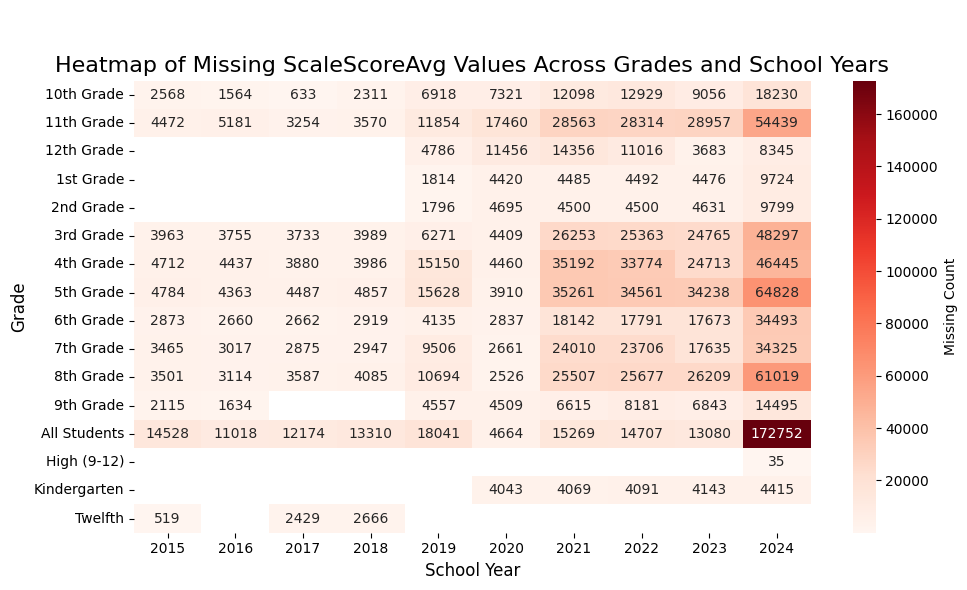

```
- This heatmap shows the distribution of missing values in ScaleScoreAvg across grades and school years using shades of red.
- Darker shades indicate a higher count of missing values, highlighting potential data quality issues.
```

```python
# Load your dataset
df = pd.read_csv("1_assessment.csv")

df.loc[df.sample(frac=0.2).index, 'ScaleScoreAvg'] = None

# Create a pivot table that counts the missing values in ScaleScoreAvg for each Grade and School Year
heatmap_data_missing = df.pivot_table(
    values='ScaleScoreAvg',
    index='Grade',
    columns='School Year',
    aggfunc=lambda x: x.isnull().sum()
)

plt.figure(figsize=(10, 6))
sns.heatmap(
    heatmap_data_missing,
    annot=True,
    fmt='.0f',
    cmap='Reds',
    cbar_kws={'label': 'Missing Count'}
)
plt.title("\n\nHeatmap of Missing ScaleScoreAvg Values Across Grades and School Years", fontsize=16)
plt.xlabel("School Year", fontsize=12)
plt.ylabel("Grade", fontsize=12)
plt.tight_layout()
plt.show()

print("- This heatmap shows the distribution of missing values in ScaleScoreAvg across grades and school years using shades of red.")
print("- Darker shades indicate a higher count of missing values, highlighting potential data quality issues.")
```

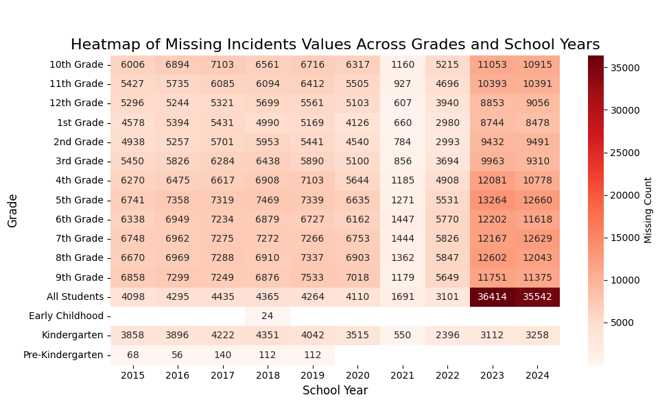

```
- This heatmap shows the distribution of missing values in Incidents across grades and school years using shades of red.
- Darker shades indicate a higher count of missing values, highlighting potential data quality issues.
```

```python
# Load your dataset
df = pd.read_csv("1_discipline.csv")

df.loc[df.sample(frac=0.2).index, 'Incidents'] = None

# Create a pivot table that counts the missing values for each Grade and School Year
heatmap_data_missing = df.pivot_table(
    values='Incidents',
    index='Grade',
    columns='School Year',
    aggfunc=lambda x: x.isnull().sum()
)

plt.figure(figsize=(10, 6))
sns.heatmap(
    heatmap_data_missing,
    annot=True,
    fmt='.0f',
    cmap='Reds',
    cbar_kws={'label': 'Missing Count'}
)
plt.title("\n\nHeatmap of Missing Incidents Values Across Grades and School Years", fontsize=16)
plt.xlabel("School Year", fontsize=12)
plt.ylabel("Grade", fontsize=12)
plt.tight_layout()
plt.show()

print("- This heatmap shows the distribution of missing values in Incidents across grades and school years using shades of red.")
print("- Darker shades indicate a higher count of missing values, highlighting potential data quality issues.")
```

### **After checking the datasets,**

- Standardized column School Year

#### Upon checking the heatmap, I noticed that several years of data are missing for dataset assessment. To ensure data quality, these years are dropped for both datasets.

```python
# Load datasets
assessment = pd.read_csv('1_assessment.csv')
discipline = pd.read_csv('1_discipline.csv')

# Function to standardize the 'School Year' column to a 4-digit integer format
def standardize_school_year(df, column_name='School Year'):
    # Convert to string and extract the first four digits as the school year
    df[column_name] = df[column_name].astype(str).str.extract(r'(\d{4})')[0].astype(float)

    # Drop rows with invalid or missing years
    df.dropna(subset=[column_name], inplace=True)

    # Convert to integer type
    df[column_name] = df[column_name].astype(int)

    return df

# Standardize the 'School Year' column in both datasets
assessment = standardize_school_year(assessment, 'School Year')
discipline = standardize_school_year(discipline, 'School Year')

# Drop rows with years 2015, 2016, 2017, 2018, and 2024
years_to_drop = [2015, 2016, 2017, 2018, 2024]
assessment = assessment[~assessment['School Year'].isin(years_to_drop)]
discipline = discipline[~discipline['School Year'].isin(years_to_drop)]

# Display the unique school years to verify
print("Unique 'School Year' values in Assessment dataset:", assessment['School Year'].unique())
print("Unique 'School Year' values in Discipline dataset:", discipline['School Year'].unique())

# Save cleaned datasets
assessment.to_csv('1_assessment_cleaned.csv', index=False)
discipline.to_csv('1_discipline_cleaned.csv', index=False)
```

```
Unique 'School Year' values in Assessment dataset: [2019 2023 2020 2021 2022]
Unique 'School Year' values in Discipline dataset: [2022 2021 2019 2020 2023]
```

#### **Checking the columns for each dataset**

```python
#  Checking columns for both original datasets
#  Datasets involve in this cell and process:
#            1. assessment.csv
#            2. discipline.csv


# Load the datasets
assessment = pd.read_csv('1_assessment_cleaned.csv')
discipline = pd.read_csv('1_discipline_cleaned.csv')

# Get the unique column names from both datasets
assessment_columns = set(assessment.columns)
discipline_columns = set(discipline.columns)

# Display unique column names
print("\n\nUnique columns in assessment Dataset:\n", assessment_columns)
print("\nUnique columns in Discipline Dataset:\n", discipline_columns)

# Columns in both datasets
common_columns = assessment_columns.intersection(discipline_columns)
print("\nColumns common in both datasets:\n", common_columns)

# Columns unique to each dataset
assessment_unique = assessment_columns - discipline_columns
discipline_unique = discipline_columns - assessment_columns

print("\nColumns unique to Assessment Dataset:\n", assessment_unique)
print("\nColumns unique to Discipline Dataset:\n", discipline_unique)
```

```
Unique columns in assessment Dataset:
 {'Assessment Name', 'Organization', 'School Code', 'ScaleScoreAvg', 'Grade', 'District', 'Proficient', 'School Year', 'District Code', 'Race', 'ContentArea', 'RowStatus', 'Gender', 'Geography', 'Tested', 'SubGroup', 'SpecialDemo', 'PctProficient'}

Unique columns in Discipline Dataset:
 {'Organization', 'School Code', 'Grade', 'District', 'Enrollment', 'School Year', 'District Code', 'Race', 'RowStatus', 'Gender', 'Geography', 'Category', 'SubGroup', 'Incidents', 'SpecialDemo', 'AvgDuration', 'Students', 'PctEnrollment'}

Columns common in both datasets:
 {'Organization', 'School Code', 'Grade', 'District', 'School Year', 'District Code', 'Race', 'RowStatus', 'Gender', 'Geography', 'SubGroup', 'SpecialDemo'}

Columns unique to Assessment Dataset:
 {'Assessment Name', 'ScaleScoreAvg', 'Proficient', 'ContentArea', 'Tested', 'PctProficient'}

Columns unique to Discipline Dataset:
 {'Enrollment', 'Category', 'Incidents', 'AvgDuration', 'Students', 'PctEnrollment'}
```

#### **Merging/Combining two datasets**

```python
# ==================================================
#  Merging/Combining two datasets
#  Datasets involve in this cell and process:
#            1. assessment.csv
#            2. discipline.csv
# ==================================================


# Load the datasets
assessment = pd.read_csv('1_assessment_cleaned.csv')
discipline = pd.read_csv('1_discipline_cleaned.csv')

# 1. Rename the column 'Rowstatus' in dataset 'discipline.csv' into 'RowStatus'. This part is only a precaution, just in case the column name
#    did not work.
discipline.rename(columns={'Rowstatus': 'RowStatus'}, inplace=True)

# 2. Merging 2 datasets using join
# 2.a Identify common columns and unique columns
common_columns = ['SpecialDemo', 'Geography', 'School Year', 'District', 'Organization',
                  'RowStatus', 'SubGroup', 'Gender', 'Race', 'School Code', 'District Code', 'Grade']

unique_assessment_columns = ['PctProficient', 'Proficient', 'ScaleScoreAvg', 'Assessment Name',
                             'Tested', 'ContentArea']

unique_discipline_columns = ['Students', 'Enrollment', 'Incidents', 'PctEnrollment',
                             'Category', 'AvgDuration']

# 2.b Perform the inner join on common columns
merged_df = pd.merge(assessment, discipline, on=list(common_columns), how='inner')

# 2.c Add the unique columns from the Assessment dataset
for col in unique_assessment_columns:
    if col in assessment.columns:
        merged_df[col] = assessment[col]

# 2.d Add the unique columns from the Discipline dataset
for col in unique_discipline_columns:
    if col in discipline.columns:
        merged_df[col] = discipline[col]


# Save the result to a CSV file
output_file = '2_merged.csv'
merged_df.to_csv(output_file, index=False)

print(f"\n\nMerged dataset saved to '{output_file}'.\n\n")
```

```
Merged dataset saved to '2_merged.csv'.
```

#### **Merged df: Quality and Tidiness Issues Inspection**

```python
# ==================================================
# Call functions for quality and tidiness inspection
#    Dataset - merged.csv
# ==================================================
# Note: Call these functions in this specific order


# Load the dataset - final_merged_df
df = pd.read_csv("2_merged.csv")
dataset_name = "2_merged.csv"

# Call the analyze_dataset function
analyze_dataset(df, dataset_name)

# Check tidiness issues
tidiness_issue_inspection(df, dataset_name)

# Call the function for Quality Issues Inspection 1
quality_issue_inspection_part1(df, dataset_name)

# Call the function for Quality Issues Inspection 2
quality_issue_inspection_part2(df, dataset_name)
```

```
Dataset: 2_merged.csv

Total number of rows: 697305
Total number of columns: 24


First 3 rows of the dataset:
```

|  | School Year | District Code | District | School Code | Organization | Assessment Name | ContentArea | Race | Gender | Grade | SpecialDemo | Geography | SubGroup | RowStatus | Tested | Proficient | PctProficient | ScaleScoreAvg | Category | Students | Enrollment | PctEnrollment | Incidents | AvgDuration |
| --- | --- | --- | --- | --- | --- | --- | --- | --- | --- | --- | --- | --- | --- | --- | --- | --- | --- | --- | --- | --- | --- | --- | --- | --- |
| 0 | 2019 | 16 | Laurel School District | 0 | Laurel School District | Annual EL ACCESS | CMP | All Students | Male | 11th Grade | All Students | All Students | Male/11th Grade | REDACTED | NaN | NaN | NaN | NaN | In-School Suspension | 18.0 | 1919.0 | 0.94 | 27.0 | 0.7 |
| 1 | 2019 | 16 | Laurel School District | 0 | Laurel School District | Annual EL ACCESS | CMP | All Students | Male | 11th Grade | All Students | All Students | Male/11th Grade | REDACTED | NaN | NaN | NaN | NaN | Out-of-School Suspension | NaN | NaN | NaN | NaN | NaN |
| 2 | 2019 | 16 | Laurel School District | 0 | Laurel School District | Annual EL ACCESS | CMP | All Students | Male | 12th Grade | All Students | All Students | Male/12th Grade | REDACTED | NaN | NaN | NaN | NaN | In-School Suspension | 43.0 | 617.0 | 6.97 | 59.0 | 1.1 |

```
All Columns in the Dataset:
['School Year', 'District Code', 'District', 'School Code', 'Organization', 'Assessment Name', 'ContentArea', 'Race', 'Gender', 'Grade', 'SpecialDemo', 'Geography', 'SubGroup', 'RowStatus', 'Tested', 'Proficient', 'PctProficient', 'ScaleScoreAvg', 'Category', 'Students', 'Enrollment', 'PctEnrollment…

No repeated columns found.


 ---------------------- Tidiness Issues Inspection ----------------------

Dataset: 2_merged.csv


1. Column Headers as Values:
   None

2. Wide Format Instead of Long Format:
   None

3. Poorly Named Columns:
   None

4. Inconsistent Data Structure:
   None

5. Unnecessary Columns:
   Unnecessary columns detected: ['Geography']

6. Mixed Granularity:
   Potential mixed granularity detected in columns: ['School Year', 'District Code', 'School Code', 'Tested', 'Proficient', 'PctProficient', 'ScaleScoreAvg', 'Students', 'Enrollment', 'PctEnrollment', 'Incidents', 'AvgDuration']

7. Repeated Index or Hierarchical Issues:
   Index is unique.

   Index is not a MultiIndex. No hierarchical issues detected.



 ---------------------- Quality Issues Inspection Part 1 ----------------------

Dataset: 2_merged.csv

```

[output cut: 107 more lines]

```
         Gender              Reencode (Standardize categories)
          Grade Reengineer (Separate numeric values and units)
    SpecialDemo              Reencode (Standardize categories)
      Geography              Reencode (Standardize categories)
       SubGroup Reengineer (Separate numeric values and units)
      RowStatus              Reencode (Standardize categories)
       Category              Reencode (Standardize categories)


3. Unique Categorical Values:

Unique categorical values (delete if not needed) saved to '2_merged.csv_unique_categorical_values.csv'.


4. Analyzing Dataset: '2_merged.csv' for data types and classification
```

|  | Column | Data Type | Classification | Correct/Incorrect Data Type | Unique Values | Sample Values |
| --- | --- | --- | --- | --- | --- | --- |
| School Year | School Year | int64 | ordinal | Correct | 5 | [2019, 2023, 2020, 2021, 2022] |
| District Code | District Code | int64 | numeric | Correct | 43 | [16, 0, 10, 13, 15] |
| District | District | object | categorical | Correct | 44 | [Laurel School District, State of Delaware, Caesar Rodney School District, Capital School District, Lake Forest School District] |
| School Code | School Code | int64 | numeric | Correct | 221 | [0, 610, 611, 612, 615] |
| Organization | Organization | object | categorical | Correct | 257 | [Laurel School District, State of Delaware, Caesar Rodney School District, Allen Frear Elementary School, J. Ralph McIlvaine Early Childhood Center] |
| Assessment Name | Assessment Name | object | categorical | Correct | 6 | [Annual EL ACCESS, DeSSA Alternate Assessment, SAT School-Day (Spring), Smarter Balanced Summative Assessment, Annual EL ACCESS-Alt] |
| ContentArea | ContentArea | object | categorical | Correct | 7 | [CMP, ELA, MATH, SCI, ESSAY] |
| Race | Race | object | categorical | Correct | 8 | [All Students, Hispanic/Latino, Native American, African American, White] |
| Gender | Gender | object | categorical | Correct | 3 | [Male, All Students, Female] |
| Grade | Grade | object | categorical | Correct | 14 | [11th Grade, 12th Grade, 1st Grade, 2nd Grade, 3rd Grade] |
| SpecialDemo | SpecialDemo | object | categorical | Correct | 12 | [All Students, Active EL Students, Low-Income, Military Connected Youth, Students with Disabilities] |
| Geography | Geography | object | categorical | Correct | 1 | [All Students] |
| SubGroup | SubGroup | object | categorical | Correct | 1704 | [Male/11th Grade, Male/12th Grade, Hispanic/Latino/1st Grade, Hispanic/Latino/2nd Grade, Hispanic/Latino/3rd Grade] |
| RowStatus | RowStatus | object | categorical | Correct | 2 | [REDACTED, REPORTED] |
| Tested | Tested | float64 | numeric | Correct | 2396 | [1206.0, 1220.0, 1317.0, 1274.0, 1045.0] |
| Proficient | Proficient | float64 | numeric | Correct | 1394 | [13.0, 31.0, 48.0, 253.0, 241.0] |
| PctProficient | PctProficient | float64 | numeric | Correct | 7335 | [1.08, 2.54, 3.64, 19.86, 23.06] |
| ScaleScoreAvg | ScaleScoreAvg | float64 | numeric | Correct | 35059 | [280.19, 307.44, 326.11, 358.36, 368.05] |
| Category | Category | object | categorical | Correct | 7 | [In-School Suspension, Out-of-School Suspension, Out-of-School Suspension without CDAP Placement, Out-of-School Suspension with CDAP Placement, Expulsion (Permanent Removal from School)] |
| Students | Students | float64 | numeric | Correct | 1251 | [18.0, 43.0, 21.0, 76.0, 30.0] |
| Enrollment | Enrollment | float64 | numeric | Correct | 3622 | [1919.0, 617.0, 28.0, 121.0, 384.0] |
| PctEnrollment | PctEnrollment | float64 | numeric | Correct | 4142 | [0.94, 6.97, 17.36, 19.79, 1.56] |
| Incidents | Incidents | float64 | numeric | Correct | 1812 | [27.0, 59.0, 38.0, 219.0, 65.0] |
| AvgDuration | AvgDuration | float64 | numeric | Correct | 2981 | [0.7, 1.1, 1.15, 1.18, 1.25] |

#### **Assessing the merged df for categorical variables and missing values**

#### **Perform a categorical assessment on the newly merged dataset to identify which columns require reencoding and reengineering.**

```python
### Call the function to assess categorical class

# Load the  dataset
main_df = pd.read_csv("2_merged.csv", low_memory=False)
dataset_name = "2_merged.csv"

# other way of using this function: Without a feature summary DataFrame
# assess_categorical_variables(main_df, dataset_name)
```

[output not shown]

#### Examine the missing data across both columns and rows.

```python
df = pd.read_csv("2_merged.csv")

# Determine missing data percentage in each column
missing_data_percent = (df.isnull().sum() / len(df)) * 100
threshold = 30  # Set threshold for excessive missing data

# Define thresholds for high, low, and no missing data
high_missing_threshold = 30  # Columns with more than 30% missing data
low_missing_threshold = 1  # Columns with 1% to 30% missing data

total_columns = df.shape[1]

# Identify columns for each subset
columns_high_missing = missing_data_percent[missing_data_percent > high_missing_threshold].index
columns_low_missing = missing_data_percent[(missing_data_percent <= high_missing_threshold) & (missing_data_percent > low_missing_threshold)].index
columns_no_missing = missing_data_percent[missing_data_percent == 0].index

# Create subsets of the dataset based on columns with different levels of missing data
subset_high_missing_columns = df[columns_high_missing]
subset_low_missing_columns = df[columns_low_missing]
subset_no_missing_columns = df[columns_no_missing]

# Count the number of columns in each subset
num_columns_high_missing = len(columns_high_missing)
num_columns_low_missing = len(columns_low_missing)
num_columns_no_missing = len(columns_no_missing)

# Calculate percentages of each subset relative to the total columns
percent_columns_high_missing = (num_columns_high_missing / total_columns) * 100
percent_columns_low_missing = (num_columns_low_missing / total_columns) * 100
percent_columns_no_missing = (num_columns_no_missing / total_columns) * 100


# Print the count of columns and save messages
print(f"\033[1m\n\nColumns with high missing values: These are columns with more than {threshold}% missing data.\033[0m")
print(f"\033[1mColumns with high missing values: {num_columns_high_missing}.\033[0m")
print(columns_high_missing)
print(f"These columns (columns with high missing values) make up {percent_columns_high_missing:.2f}% of the entire dataset.")

print(f"\033[1m\nColumns with low missing values: These are columns with 1% to {threshold}% missing data.\033[0m")
print(f"\033[1mColumns with low missing values: {num_columns_low_missing}.\033[0m")
print(columns_low_missing)
print(f"These columns (columns with low missing values) make up {percent_columns_low_missing:.2f}% of the entire dataset.")

print(f"\033[1m\nColumns without missing values: These are columns with 0% missing data.\033[0m")
print(f"\033[1mColumns without missing values: {num_columns_no_missing}.\033[0m")
print(columns_no_missing)
print(f"These columns (columns without missing values) make up {percent_columns_no_missing:.2f}% of the entire dataset.")

print("\033[1;32m\n\nAll requests processed successfully!\033[0m\n\n")  # Success message


###################################################################

#  Calculate the percentage of missing data in each row
missing_data_percent_rows = (df.isnull().sum(axis=1) / df.shape[1]) * 100

#  Identify rows with more than a threshold percentage of missing data
threshold = 30  # Set threshold for excessive missing data
outlier_rows = missing_data_percent_rows[missing_data_percent_rows > threshold].index

#  Divide the data into two subsets based on row-wise missing values
subset_high_missing = df.loc[outlier_rows]  # Rows with many missing values
subset_low_missing = df.drop(outlier_rows)  # Rows with fewer missing values

# Identify rows with no missing values
subset_no_missing = df.dropna()  # Rows without any missing values

# Count the total number of rows (excluding the header row)
total_rows = df.shape[0]

# Count the number of rows in each subset
num_rows_high_missing = subset_high_missing.shape[0]   # Count rows with high missing values
num_rows_low_missing = subset_low_missing.shape[0]  # Count rows with low missing values
num_rows_no_missing = subset_no_missing.shape[0]  # Count rows without missing values

# Calculate percentages of each subset against the total rows
percent_high_missing = (num_rows_high_missing / total_rows) * 100
percent_low_missing = (num_rows_low_missing / total_rows) * 100
percent_no_missing = (num_rows_no_missing / total_rows) * 100

# Print the count of rows and save messages, along with percentages
print(f"\033[1m\n\nTotal rows in dataset: {total_rows}\033[0m")

print(f"\033[1m\nRows with high missing values: These are rows with more than {threshold}% missing data.\033[0m")
print(f"\033[1mRows with high missing values: {num_rows_high_missing} ({percent_high_missing:.2f}% of the entire dataset)'.\033[0m")

print(f"\033[1m\nRows with low missing values: These are rows with 1% to {threshold}% missing data.\033[0m")
print(f"\033[1mRows with low missing values: {num_rows_low_missing} ({percent_low_missing:.2f}% of the entire dataset)'.\033[0m")

print(f"\033[1m\nRows without missing values: These are rows with 0% missing data.\033[0m")
print(f"\033[1mRows without missing values: {num_rows_no_missing} ({percent_no_missing:.2f}% of the entire dataset)'.\033[0m\n")

print("\033[1;32m\n\nAll requests processed successfully!\033[0m\n\n")  # Success message
```

```
Columns with high missing values: These are columns with more than 30% missing data.
Columns with high missing values: 9.
Index(['Tested', 'Proficient', 'PctProficient', 'ScaleScoreAvg', 'Students',
       'Enrollment', 'PctEnrollment', 'Incidents', 'AvgDuration'],
      dtype='object')
These columns (columns with high missing values) make up 37.50% of the entire dataset.

Columns with low missing values: These are columns with 1% to 30% missing data.
Columns with low missing values: 1.
Index(['Category'], dtype='object')
These columns (columns with low missing values) make up 4.17% of the entire dataset.

Columns without missing values: These are columns with 0% missing data.
Columns without missing values: 14.
Index(['School Year', 'District Code', 'District', 'School Code',
       'Organization', 'Assessment Name', 'ContentArea', 'Race', 'Gender',
       'Grade', 'SpecialDemo', 'Geography', 'SubGroup', 'RowStatus'],
      dtype='object')
These columns (columns without missing values) make up 58.33% of the entire dataset.


All requests processed successfully!




Total rows in dataset: 697305

Rows with high missing values: These are rows with more than 30% missing data.
Rows with high missing values: 344986 (49.47% of the entire dataset)'.

Rows with low missing values: These are rows with 1% to 30% missing data.
Rows with low missing values: 352319 (50.53% of the entire dataset)'.

Rows without missing values: These are rows with 0% missing data.
Rows without missing values: 22897 (3.28% of the entire dataset)'.



All requests processed successfully!
```

#### **After examining the missing values, I found that they are intentional due to redacted information concerning protected demographics. Therefore, these columns will be retained, and imputation will be applied to columns containing empirical values.**

```python
# Load the dataset - merged_cleaned
df = pd.read_csv("2_merged.csv")
dataset_name = "2_merged.csv"

# Call the analyze_dataset function
analyze_dataset(df, dataset_name)

# Check tidiness issues
tidiness_issue_inspection(df, dataset_name)

# Call the function for Quality Issues Inspection 1
quality_issue_inspection_part1(df, dataset_name)

# Call the function for Quality Issues Inspection 2
quality_issue_inspection_part2(df, dataset_name)
```

```
Dataset: 2_merged.csv

Total number of rows: 697305
Total number of columns: 24


First 3 rows of the dataset:
```

|  | School Year | District Code | District | School Code | Organization | Assessment Name | ContentArea | Race | Gender | Grade | SpecialDemo | Geography | SubGroup | RowStatus | Tested | Proficient | PctProficient | ScaleScoreAvg | Category | Students | Enrollment | PctEnrollment | Incidents | AvgDuration |
| --- | --- | --- | --- | --- | --- | --- | --- | --- | --- | --- | --- | --- | --- | --- | --- | --- | --- | --- | --- | --- | --- | --- | --- | --- |
| 0 | 2019 | 16 | Laurel School District | 0 | Laurel School District | Annual EL ACCESS | CMP | All Students | Male | 11th Grade | All Students | All Students | Male/11th Grade | REDACTED | NaN | NaN | NaN | NaN | In-School Suspension | 18.0 | 1919.0 | 0.94 | 27.0 | 0.7 |
| 1 | 2019 | 16 | Laurel School District | 0 | Laurel School District | Annual EL ACCESS | CMP | All Students | Male | 11th Grade | All Students | All Students | Male/11th Grade | REDACTED | NaN | NaN | NaN | NaN | Out-of-School Suspension | NaN | NaN | NaN | NaN | NaN |
| 2 | 2019 | 16 | Laurel School District | 0 | Laurel School District | Annual EL ACCESS | CMP | All Students | Male | 12th Grade | All Students | All Students | Male/12th Grade | REDACTED | NaN | NaN | NaN | NaN | In-School Suspension | 43.0 | 617.0 | 6.97 | 59.0 | 1.1 |

```
All Columns in the Dataset:
['School Year', 'District Code', 'District', 'School Code', 'Organization', 'Assessment Name', 'ContentArea', 'Race', 'Gender', 'Grade', 'SpecialDemo', 'Geography', 'SubGroup', 'RowStatus', 'Tested', 'Proficient', 'PctProficient', 'ScaleScoreAvg', 'Category', 'Students', 'Enrollment', 'PctEnrollment…

No repeated columns found.


 ---------------------- Tidiness Issues Inspection ----------------------

Dataset: 2_merged.csv


1. Column Headers as Values:
   None

2. Wide Format Instead of Long Format:
   None

3. Poorly Named Columns:
   None

4. Inconsistent Data Structure:
   None

5. Unnecessary Columns:
   Unnecessary columns detected: ['Geography']

6. Mixed Granularity:
   Potential mixed granularity detected in columns: ['School Year', 'District Code', 'School Code', 'Tested', 'Proficient', 'PctProficient', 'ScaleScoreAvg', 'Students', 'Enrollment', 'PctEnrollment', 'Incidents', 'AvgDuration']

7. Repeated Index or Hierarchical Issues:
   Index is unique.

   Index is not a MultiIndex. No hierarchical issues detected.



 ---------------------- Quality Issues Inspection Part 1 ----------------------

Dataset: 2_merged.csv

```

[output cut: 107 more lines]

```
         Gender              Reencode (Standardize categories)
          Grade Reengineer (Separate numeric values and units)
    SpecialDemo              Reencode (Standardize categories)
      Geography              Reencode (Standardize categories)
       SubGroup Reengineer (Separate numeric values and units)
      RowStatus              Reencode (Standardize categories)
       Category              Reencode (Standardize categories)


3. Unique Categorical Values:

Unique categorical values (delete if not needed) saved to '2_merged.csv_unique_categorical_values.csv'.


4. Analyzing Dataset: '2_merged.csv' for data types and classification
```

|  | Column | Data Type | Classification | Correct/Incorrect Data Type | Unique Values | Sample Values |
| --- | --- | --- | --- | --- | --- | --- |
| School Year | School Year | int64 | ordinal | Correct | 5 | [2019, 2023, 2020, 2021, 2022] |
| District Code | District Code | int64 | numeric | Correct | 43 | [16, 0, 10, 13, 15] |
| District | District | object | categorical | Correct | 44 | [Laurel School District, State of Delaware, Caesar Rodney School District, Capital School District, Lake Forest School District] |
| School Code | School Code | int64 | numeric | Correct | 221 | [0, 610, 611, 612, 615] |
| Organization | Organization | object | categorical | Correct | 257 | [Laurel School District, State of Delaware, Caesar Rodney School District, Allen Frear Elementary School, J. Ralph McIlvaine Early Childhood Center] |
| Assessment Name | Assessment Name | object | categorical | Correct | 6 | [Annual EL ACCESS, DeSSA Alternate Assessment, SAT School-Day (Spring), Smarter Balanced Summative Assessment, Annual EL ACCESS-Alt] |
| ContentArea | ContentArea | object | categorical | Correct | 7 | [CMP, ELA, MATH, SCI, ESSAY] |
| Race | Race | object | categorical | Correct | 8 | [All Students, Hispanic/Latino, Native American, African American, White] |
| Gender | Gender | object | categorical | Correct | 3 | [Male, All Students, Female] |
| Grade | Grade | object | categorical | Correct | 14 | [11th Grade, 12th Grade, 1st Grade, 2nd Grade, 3rd Grade] |
| SpecialDemo | SpecialDemo | object | categorical | Correct | 12 | [All Students, Active EL Students, Low-Income, Military Connected Youth, Students with Disabilities] |
| Geography | Geography | object | categorical | Correct | 1 | [All Students] |
| SubGroup | SubGroup | object | categorical | Correct | 1704 | [Male/11th Grade, Male/12th Grade, Hispanic/Latino/1st Grade, Hispanic/Latino/2nd Grade, Hispanic/Latino/3rd Grade] |
| RowStatus | RowStatus | object | categorical | Correct | 2 | [REDACTED, REPORTED] |
| Tested | Tested | float64 | numeric | Correct | 2396 | [1206.0, 1220.0, 1317.0, 1274.0, 1045.0] |
| Proficient | Proficient | float64 | numeric | Correct | 1394 | [13.0, 31.0, 48.0, 253.0, 241.0] |
| PctProficient | PctProficient | float64 | numeric | Correct | 7335 | [1.08, 2.54, 3.64, 19.86, 23.06] |
| ScaleScoreAvg | ScaleScoreAvg | float64 | numeric | Correct | 35059 | [280.19, 307.44, 326.11, 358.36, 368.05] |
| Category | Category | object | categorical | Correct | 7 | [In-School Suspension, Out-of-School Suspension, Out-of-School Suspension without CDAP Placement, Out-of-School Suspension with CDAP Placement, Expulsion (Permanent Removal from School)] |
| Students | Students | float64 | numeric | Correct | 1251 | [18.0, 43.0, 21.0, 76.0, 30.0] |
| Enrollment | Enrollment | float64 | numeric | Correct | 3622 | [1919.0, 617.0, 28.0, 121.0, 384.0] |
| PctEnrollment | PctEnrollment | float64 | numeric | Correct | 4142 | [0.94, 6.97, 17.36, 19.79, 1.56] |
| Incidents | Incidents | float64 | numeric | Correct | 1812 | [27.0, 59.0, 38.0, 219.0, 65.0] |
| AvgDuration | AvgDuration | float64 | numeric | Correct | 2981 | [0.7, 1.1, 1.15, 1.18, 1.25] |

#### **Cleaning the dataset and ensuring it is ready for model training**

#### Cleaning starts with this dataset: 2_merged.csv

##### Datasets saved throughout the process.

> 3_cleaned_part1.csv, 3_cleaned_part2.csv, 3_cleaned_part3.csv, 3_cleaned_part4.csv